# Analisis Pemulusan (Smoothing) Data Time Series

Harga Penutupan Saham BBCA - Bagian: Silvia

Silvia

01 September 2026

## 1. Deskripsi Data

Data yang digunakan adalah **harga penutupan (Close) harian saham BBCA** periode 2020-2026 (total 1604 observasi), dibaca langsung dari file asli `BBCA_Close_2020_2026.csv`. Data dibagi rata ke 6 anggota kelompok. Bagian **Silvia** adalah observasi ke-1333 hingga ke-1600, yaitu periode **17 Juli 2025 - 17 Agustus 2026** (268 observasi).

Terdapat 4 tanggal dengan nilai kosong (hari bursa libur namun tercatat di data mentah). Nilai-nilai tersebut diisi dengan **interpolasi linear** (dilakukan pada data lengkap sebelum dipotong, supaya nilai kosong di ujung potongan tetap punya tetangga kiri/kanan untuk diinterpolasi).

```r
df_full <- read.csv("BBCA_Close_2020_2026.csv", stringsAsFactors = FALSE)
colnames(df_full) <- c("tanggal", "close")
df_full$tanggal <- as.Date(df_full$tanggal)
df_full$close   <- na.approx(df_full$close, na.rm = FALSE)

df <- df_full[1333:1600, ]        # bagian Silvia
rownames(df) <- NULL

n <- nrow(df)
y <- ts(df$close, frequency = 5)   # frekuensi 5 = hari bursa per minggu

knitr::kable(head(df, 6), caption = "6 observasi pertama data Silvia")
```

6 observasi pertama data Silvia

| tanggal | close |
| --- | --- |
| 2025-07-17 | 8525 |
| 2025-07-18 | 8425 |
| 2025-07-21 | 8450 |
| 2025-07-22 | 8400 |
| 2025-07-23 | 8425 |
| 2025-07-24 | 8500 |

Ringkasan statistik deskriptif:

```r
summary(df$close)
```

```
##    Min. 1st Qu.  Median    Mean 3rd Qu.    Max.
##    4850    6319    7425    7267    8175    8925
```

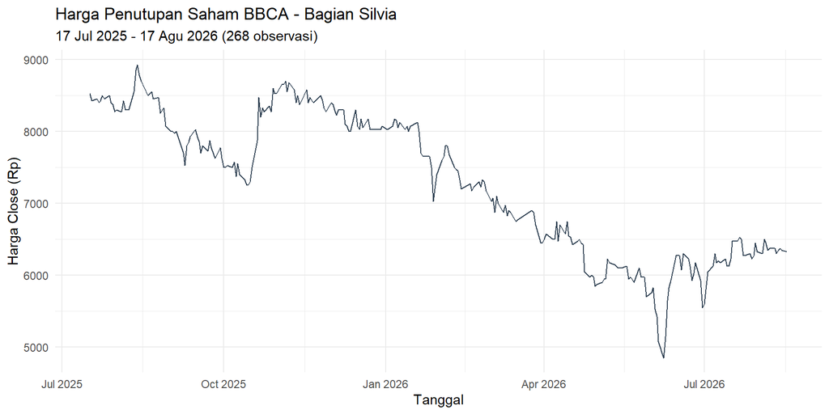

```r
ggplot(df, aes(x = tanggal, y = close)) +
  geom_line(color = "#2c3e50") +
  labs(title = "Harga Penutupan Saham BBCA - Bagian Silvia",
       subtitle = "17 Jul 2025 - 17 Agu 2026 (268 observasi)",
       x = "Tanggal", y = "Harga Close (Rp)") +
  theme_minimal()
```

Dari plot terlihat harga bergerak dengan **tren turun bertahap** disertai fluktuasi harian yang tidak beraturan, tanpa pola musiman mingguan yang jelas (wajar, karena data adalah hari bursa saja / weekend tidak ada transaksi). Karakteristik inilah yang menentukan metode pemulusan mana yang paling sesuai.

## 2. Fungsi Metrik Akurasi

```r
akurasi <- function(actual, fitted) {
  valid <- !is.na(fitted)
  err   <- actual[valid] - fitted[valid]
  data.frame(
    SSE  = sum(err^2), MSE = mean(err^2), RMSE = sqrt(mean(err^2)),
    MAPE = mean(abs(err / actual[valid])) * 100, n_valid = sum(valid)
  )
}
```

## 3. Metode Pemulusan

### 3.1 Simple Moving Average (SMA)

```r
m <- 5
sma_raw    <- as.numeric(stats::filter(y, rep(1/m, m), sides = 1))
sma_fitted <- c(NA, head(sma_raw, -1))
akurasi_sma <- akurasi(as.numeric(y), sma_fitted)
akurasi_sma
```

| SSE | MSE | RMSE | MAPE | n_valid |
| --- | --- | --- | --- | --- |
| 11840163 | 45019.63 | 212.1783 | 2.178166 | 263 |

### 3.2 Double Moving Average (DMA)

```r
Mt  <- as.numeric(stats::filter(y, rep(1/m, m), sides = 1))
Mt2 <- as.numeric(stats::filter(Mt, rep(1/m, m), sides = 1))
at  <- 2 * Mt - Mt2
bt  <- (2 / (m - 1)) * (Mt - Mt2)
dma_level  <- at + bt
dma_fitted <- c(NA, head(dma_level, -1))
akurasi_dma <- akurasi(as.numeric(y), dma_fitted)
akurasi_dma
```

| SSE | MSE | RMSE | MAPE | n_valid |
| --- | --- | --- | --- | --- |
| 12409787 | 47914.23 | 218.8932 | 2.244717 | 259 |

### 3.3 Single Exponential Smoothing (SES)

```r
ses_model  <- HoltWinters(y, beta = FALSE, gamma = FALSE)
ses_fitted <- c(rep(NA, n - nrow(ses_model$fitted)), ses_model$fitted[, 1])
akurasi_ses <- akurasi(as.numeric(y), ses_fitted)
cat("alpha optimum:", round(ses_model$alpha, 4), "\n")
```

```
## alpha optimum: 0.9999
```

```r
akurasi_ses
```

| SSE | MSE | RMSE | MAPE | n_valid |
| --- | --- | --- | --- | --- |
| 5490946 | 20565.34 | 143.4062 | 1.508208 | 267 |

### 3.4 Double Exponential Smoothing / Holt (DES)

```r
des_model  <- HoltWinters(y, gamma = FALSE)
des_fitted <- c(rep(NA, n - nrow(des_model$fitted)), des_model$fitted[, 1])
akurasi_des <- akurasi(as.numeric(y), des_fitted)
cat("alpha optimum:", round(des_model$alpha, 4),
    "| beta optimum:", round(des_model$beta, 4), "\n")
```

```
## alpha optimum: 1 | beta optimum: 0.0342
```

```r
akurasi_des
```

| SSE | MSE | RMSE | MAPE | n_valid |
| --- | --- | --- | --- | --- |
| 5733805 | 21555.66 | 146.8185 | 1.562534 | 266 |

### 3.5 Holt-Winters (Triple Exponential Smoothing)

```r
hw_model  <- HoltWinters(y)
hw_fitted <- c(rep(NA, n - nrow(hw_model$fitted)), hw_model$fitted[, 1])
akurasi_hw <- akurasi(as.numeric(y), hw_fitted)
cat("alpha:", round(hw_model$alpha, 4),
    "| beta:", round(hw_model$beta, 4),
    "| gamma:", round(hw_model$gamma, 4), "\n")
```

```
## alpha: 0.9812 | beta: 0 | gamma: 1
```

```r
akurasi_hw
```

| SSE | MSE | RMSE | MAPE | n_valid |
| --- | --- | --- | --- | --- |
| 5738255 | 21818.46 | 147.7107 | 1.552131 | 263 |

## 4. Perbandingan Kinerja Metode

```r
hasil <- rbind(
  cbind(Metode = "SMA (m=5)", akurasi_sma),
  cbind(Metode = "DMA (m=5)", akurasi_dma),
  cbind(Metode = "SES", akurasi_ses),
  cbind(Metode = "DES (Holt)", akurasi_des),
  cbind(Metode = "Holt-Winters", akurasi_hw)
)
hasil <- hasil[order(hasil$RMSE), ]
write.csv(hasil, "hasil_perbandingan_metode_silvia_bbca.csv", row.names = FALSE)
knitr::kable(hasil, digits = 2, row.names = FALSE,
             caption = "Perbandingan metrik akurasi tiap metode (diurutkan dari terbaik)")
```

Perbandingan metrik akurasi tiap metode (diurutkan dari terbaik)

| Metode | SSE | MSE | RMSE | MAPE | n_valid |
| --- | --- | --- | --- | --- | --- |
| SES | 5490946 | 20565.34 | 143.41 | 1.51 | 267 |
| DES (Holt) | 5733805 | 21555.66 | 146.82 | 1.56 | 266 |
| Holt-Winters | 5738255 | 21818.46 | 147.71 | 1.55 | 263 |
| SMA (m=5) | 11840163 | 45019.63 | 212.18 | 2.18 | 263 |
| DMA (m=5) | 12409787 | 47914.23 | 218.89 | 2.24 | 259 |

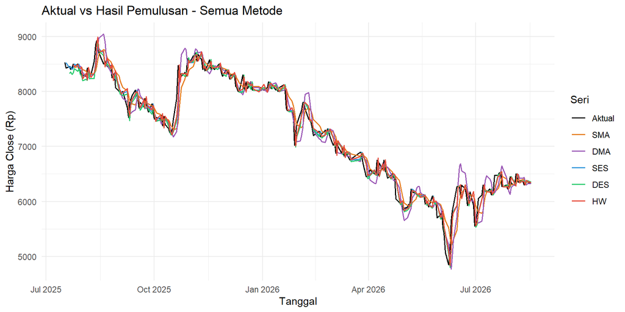

```r
plot_df <- data.frame(tanggal = df$tanggal, Aktual = df$close, SMA = sma_fitted,
                       DMA = dma_fitted, SES = ses_fitted, DES = des_fitted, HW = hw_fitted)
plot_long <- melt(plot_df, id.vars = "tanggal")

ggplot(plot_long, aes(x = tanggal, y = value, color = variable)) +
  geom_line(linewidth = 0.7) +
  scale_color_manual(values = c(Aktual = "black", SMA = "#e67e22", DMA = "#9b59b6",
                                 SES = "#3498db", DES = "#2ecc71", HW = "#e74c3c")) +
  labs(title = "Aktual vs Hasil Pemulusan - Semua Metode",
       x = "Tanggal", y = "Harga Close (Rp)", color = "Seri") +
  theme_minimal()
```

## 5. Kesimpulan

Berdasarkan hasil perbandingan, metode dengan **RMSE, MSE, SSE, dan MAPE terkecil** adalah **SES**.

**Alasan:**

1. Harga saham (Close) umumnya mengikuti pola **random walk**: nilai hari ini adalah prediktor terbaik untuk nilai besok, tanpa pola musiman mingguan yang berarti.
2. **SMA dan DMA** merata-ratakan beberapa hari terakhir sehingga pemulusannya selalu “telat” mengikuti pergerakan harga - error paling besar di antara semua metode.
3. **SES** menghasilkan parameter optimal **alpha mendekati 1**, artinya model memberi bobot hampir penuh pada observasi terakhir (mirip metode naif) - dan justru inilah yang paling akurat untuk data dengan karakteristik random walk seperti harga saham.
4. **DES** menambahkan komponen tren namun estimasi beta yang dihasilkan kecil, sehingga hasilnya mirip SES namun sedikit lebih fluktuatif - errornya sedikit lebih tinggi dari SES.
5. **Holt-Winters** menambahkan komponen musiman, padahal data harga saham memang tidak memiliki pola musiman mingguan yang nyata, sehingga komponen tambahan ini tidak memperbaiki akurasi secara berarti dibanding SES.

Oleh karena itu, **SES** adalah metode pemulusan yang paling sesuai untuk data harga saham BBCA bagian Silvia ini.